# Pemodelan ARIMA pada Kurs USD/IDR

Praktikum MPDW

Rio Faudzan Pritajaya M0401241116

30 September 2026

# Package

```r
# install.packages(c("readxl","forecast","tseries","TSA","MASS","lmtest","FinTS","ggplot2"))
library(readxl)
library(forecast)
library(tseries)
library(TSA)
library(MASS)
library(lmtest)
library(FinTS)
library(ggplot2)
```

# 0. Data dan Pembagian Data Latih-Uji

Data: kurs USD terhadap IDR (harga penutupan/*Close*) . Rentang waktunya 25 Agustus 2024 sampai 25 Agustus 2026

```r
d <- read_excel("kurs_usd_idr.xlsx")
d$Tanggal <- as.Date(d$Tanggal)
y <- d$Close
n <- length(y)
cat("Jumlah amatan:", n, "\nPeriode:", format(min(d$Tanggal)), "s.d.", format(max(d$Tanggal)), "\n")
```

```
## Jumlah amatan: 518
## Periode: 2024-08-25 s.d. 2026-08-25
```

```r
head(d)
```

| Tanggal | Open | High | Low | Close | AdjClose |
| --- | --- | --- | --- | --- | --- |
| 2024-08-25 | 15377.2 | 15471.0 | 15287.6 | 15377.2 | 15377.2 |
| 2024-08-26 | 15462.6 | 15552.9 | 15443.0 | 15462.6 | 15462.6 |
| 2024-08-27 | 15467.1 | 15520.4 | 15367.8 | 15467.1 | 15467.1 |
| 2024-08-28 | 15440.0 | 15466.1 | 15257.6 | 15440.0 | 15440.0 |
| 2024-08-29 | 15444.8 | 15527.5 | 15383.8 | 15444.8 | 15444.8 |
| 2024-09-01 | 15525.0 | 15556.3 | 15506.5 | 15525.0 | 15525.0 |

Pembagian dilakukan berurutan (tanpa diacak): 80% data latih dan 20% data uji.

```r
k     <- round(n * 0.8)
train <- y[1:k]
test  <- y[(k + 1):n]
d_tr  <- d$Tanggal[1:k]
d_te  <- d$Tanggal[(k + 1):n]
cat("Data latih:", length(train), "| Data uji:", length(test), "\n")
```

```
## Data latih: 414 | Data uji: 104
```

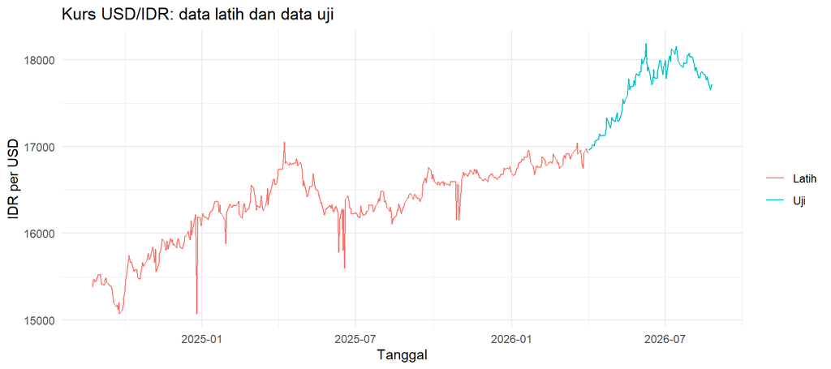

```r
ggplot() +
  geom_line(aes(d_tr, train, colour = "Latih")) +
  geom_line(aes(d_te, test,  colour = "Uji")) +
  labs(title = "Kurs USD/IDR: data latih dan data uji", x = "Tanggal", y = "IDR per USD", colour = "") +
  theme_minimal()
```

# 1. Uji Kestasioneran Data Latih

## 1.1 Stasioner dalam rataan (plot, ACF, ADF)

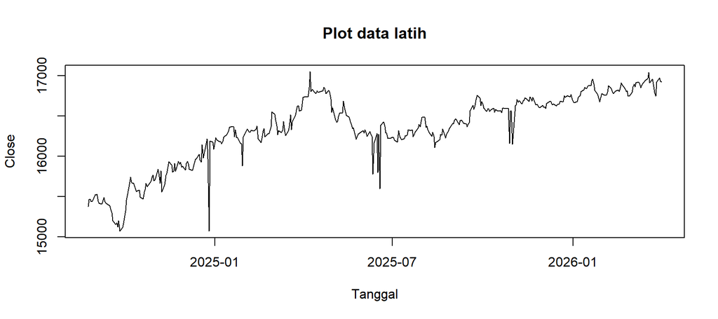

```r
plot(d_tr, train, type = "l", main = "Plot data latih", xlab = "Tanggal", ylab = "Close")
```

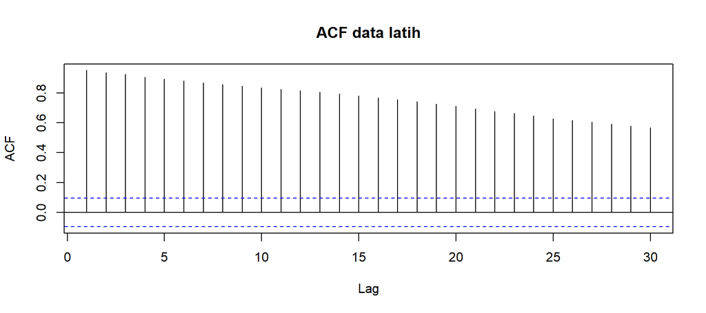

```r
acf(train, lag.max = 30, main = "ACF data latih")
```

```r
adf.test(train)
```

```
##
##  Augmented Dickey-Fuller Test
##
## data:  train
## Dickey-Fuller = -2.4462, Lag order = 7, p-value = 0.3889
## alternative hypothesis: stationary
```

H0: data tidak stasioner. Jika p-value > 0,05 maka H0 tidak ditolak, sehingga data **belum stasioner dalam rataan**. ACF yang meluruh lambat (*tails off slowly*) mendukung kesimpulan ini.

## 1.2 Stasioner dalam ragam (Box-Cox)

Data dibagi rata-rata data latih supaya skala stabil (tidak mengubah nilai $\lambda$ optimum).

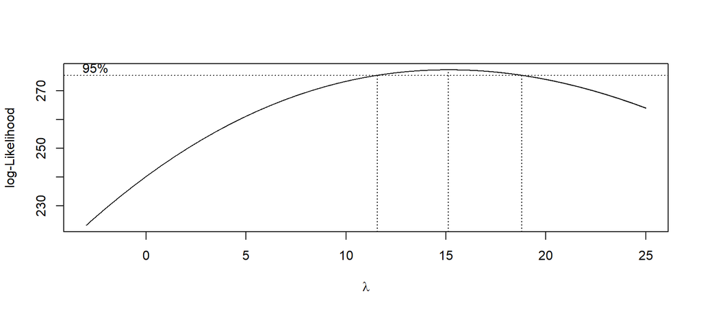

```r
sc <- mean(train)
bc <- boxcox(lm((train / sc) ~ 1), lambda = seq(-3, 25, by = 0.01))
```

```r
lambda <- bc$x[which.max(bc$y)]
ci     <- bc$x[bc$y >= max(bc$y) - 0.5 * qchisq(0.95, 1)]
cat("Lambda optimum :", round(lambda, 2), "\n")
```

```
## Lambda optimum : 15.13
```

```r
cat("Selang 95%     : [", round(min(ci), 2), ";", round(max(ci), 2), "]\n")
```

```
## Selang 95%     : [ 11.57 ; 18.79 ]
```

```r
cat("Mengandung 1?  :", min(ci) <= 1 & max(ci) >= 1, "\n")
```

```
## Mengandung 1?  : FALSE
```

Jika selang kepercayaan **tidak** mengandung angka 1, data belum stasioner dalam ragam sehingga perlu ditransformasi.

# 2. Penanganan Ketidakstasioneran

## 2.1 Transformasi Box-Cox (ragam)

$$Z_t =
\frac{(Y_t/\bar{Y}_{latih})^{\lambda} - 1}{\lambda}$$

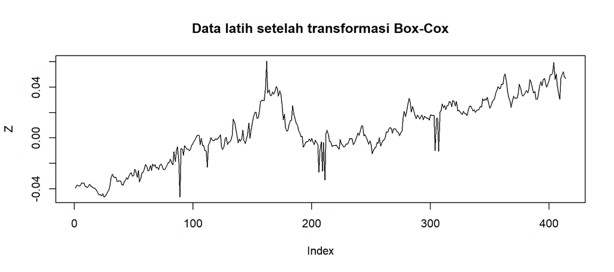

```r
bc_tr   <- function(v) ((v / sc)^lambda - 1) / lambda
ibc_tr  <- function(z) (lambda * z + 1)^(1 / lambda) * sc

z_tr  <- bc_tr(train)
z_all <- bc_tr(y)

plot(z_tr, type = "l", main = "Data latih setelah transformasi Box-Cox", ylab = "Z")
```

```r
adf.test(z_tr)
```

```
##
##  Augmented Dickey-Fuller Test
##
## data:  z_tr
## Dickey-Fuller = -2.4976, Lag order = 7, p-value = 0.3672
## alternative hypothesis: stationary
```

## 2.2 Differencing (rataan)

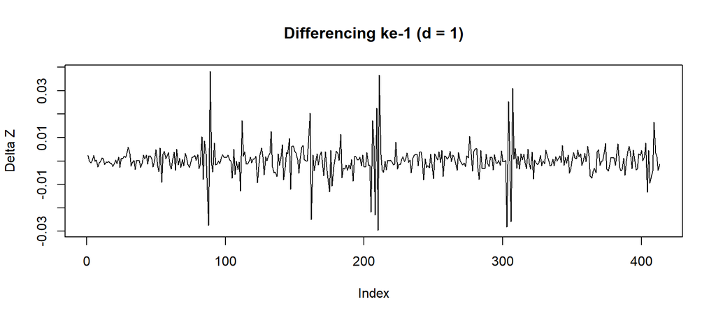

```r
dz <- diff(z_tr)
plot(dz, type = "l", main = "Differencing ke-1 (d = 1)", ylab = "Delta Z")
```

```r
adf.test(dz)
```

```
##
##  Augmented Dickey-Fuller Test
##
## data:  dz
## Dickey-Fuller = -9.1455, Lag order = 7, p-value = 0.01
## alternative hypothesis: stationary
```

Jika p-value < 0,05 maka data hasil differencing sudah **stasioner dalam rataan**, sehingga d = 1.

# 3. Identifikasi Model Potensial (ACF, PACF, EACF)

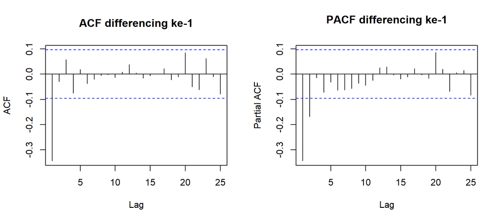

```r
par(mfrow = c(1, 2))
acf(dz,  lag.max = 25, main = "ACF differencing ke-1")
pacf(dz, lag.max = 25, main = "PACF differencing ke-1")
```

```r
par(mfrow = c(1, 1))
```

- ACF *cuts off* setelah lag 1, mengarah ke MA(1).
- PACF signifikan sampai lag 2 (meluruh), mengarah ke AR(2) atau ARMA campuran.

```r
eacf(dz, ar.max = 7, ma.max = 13)
```

```
## AR/MA
##   0 1 2 3 4 5 6 7 8 9 10 11 12 13
## 0 x o o o o o o o o o o  o  o  o
## 1 x x o o o o o o o o o  o  o  o
## 2 o x o o o o o o o o o  o  o  o
## 3 x x o o o o o o o o o  o  o  o
## 4 x x x o o o o o o o o  o  o  o
## 5 x x x x o x o o o o o  o  o  o
## 6 x o o x o o o o o o o  o  o  o
## 7 x x x x x o o o o o o  o  o  o
```

# 4. Pendugaan Parameter, Uji Signifikansi, dan AIC

```r
kand <- list(c(0,1,1), c(1,1,0), c(2,1,0), c(1,1,1),
             c(0,1,2), c(2,1,1), c(1,1,2), c(2,1,2))

fits <- lapply(kand, function(o) Arima(z_tr, order = o))
names(fits) <- sapply(kand, function(o) paste0("ARIMA(", paste(o, collapse = ","), ")"))

tabel <- do.call(rbind, lapply(names(fits), function(nm) {
  f  <- fits[[nm]]
  ct <- lmtest::coeftest(f)
  data.frame(Model = nm,
             Parameter = paste0(rownames(ct), "=", round(ct[, 1], 4),
                                " (p=", round(ct[, 4], 3), ")", collapse = "; "),
             Semua_signifikan = ifelse(all(ct[, 4] < 0.05), "Ya", "Tidak"),
             AIC = round(f$aic, 2),
             BIC = round(f$bic, 2))
}))
tabel
```

| Model | Parameter | Semua_signifikan | AIC | BIC |
| --- | --- | --- | --- | --- |
| ARIMA(0,1,1) | ma1=-0.4166 (p=0) | Ya | -3060.40 | -3052.35 |
| ARIMA(1,1,0) | ar1=-0.342 (p=0) | Ya | -3048.51 | -3040.46 |
| ARIMA(2,1,0) | ar1=-0.3988 (p=0); ar2=-0.1649 (p=0.001) | Ya | -3057.94 | -3045.87 |
| ARIMA(1,1,1) | ar1=0.0766 (p=0.593); ma1=-0.4834 (p=0) | Tidak | -3058.69 | -3046.62 |
| ARIMA(0,1,2) | ma1=-0.4077 (p=0); ma2=-0.0284 (p=0.607) | Tidak | -3058.66 | -3046.59 |
| ARIMA(2,1,1) | ar1=0.3488 (p=0.012); ar2=0.1311 (p=0.11); ma1=-0.7562 (p=0) | Tidak | -3057.95 | -3041.85 |
| ARIMA(1,1,2) | ar1=-0.7614 (p=0.003); ma1=0.3598 (p=0.159); ma2=-0.3525 (p=0) | Tidak | -3057.62 | -3041.52 |
| ARIMA(2,1,2) | ar1=-0.7753 (p=0.004); ar2=-0.0413 (p=0.802); ma1=0.3705 (p=0.168); ma2=-0.3095 (p=0.144) | Tidak | -3055.68 | -3035.56 |

Uji hipotesis tiap parameter: H0: parameter = 0 (tolak jika p-value < 0,05). Model dipilih dari yang **semua parameternya signifikan** dengan **AIC terkecil**.

```r
sig   <- tabel[tabel$Semua_signifikan == "Ya", ]
best  <- sig$Model[which.min(sig$AIC)]
model <- fits[[best]]
cat("Model terpilih:", best, "| AIC =", round(model$aic, 2), "\n")
```

```
## Model terpilih: ARIMA(0,1,1) | AIC = -3060.4
```

```r
lmtest::coeftest(model)
```

```
##
## z test of coefficients:
##
##      Estimate Std. Error z value  Pr(>|z|)
## ma1 -0.416594   0.046936 -8.8757 < 2.2e-16 ***
## ---
## Signif. codes:  0 '***' 0.001 '**' 0.01 '*' 0.05 '.' 0.1 ' ' 1
```

> Catatan: nilai AIC dari `forecast::Arima` dapat sedikit berbeda dengan software lain karena perbedaan metode penduga dan inisialisasi. Urutan perbandingan antar-model tetap dapat dipakai.

# 5. Analisis Sisaan

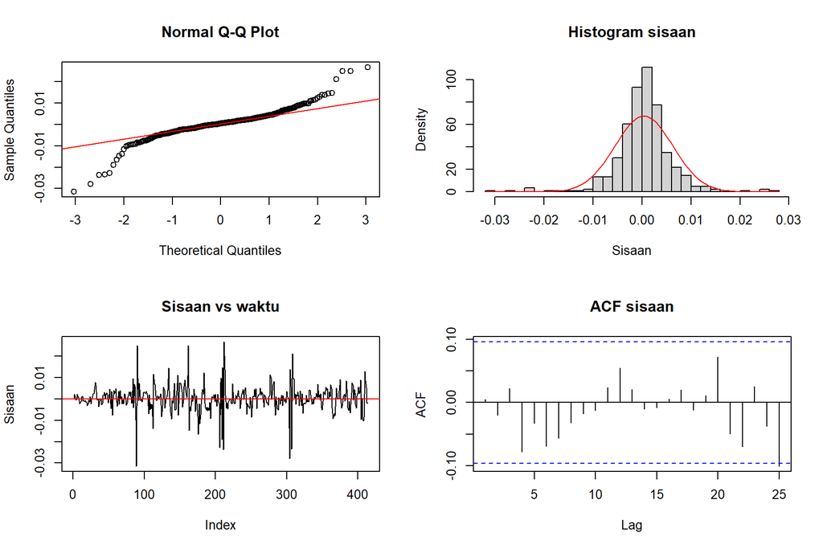

```r
res <- as.numeric(residuals(model))

par(mfrow = c(2, 2))
qqnorm(res); qqline(res, col = "red")
hist(res, breaks = 30, freq = FALSE, main = "Histogram sisaan", xlab = "Sisaan")
curve(dnorm(x, mean(res), sd(res)), add = TRUE, col = "red")
plot(res, type = "l", main = "Sisaan vs waktu", ylab = "Sisaan"); abline(h = 0, col = "red")
acf(res, lag.max = 25, main = "ACF sisaan")
```

```r
par(mfrow = c(1, 1))
```

```r
npar <- length(model$coef)
uji <- data.frame(
  Asumsi = c("Normalitas", "Normalitas", "Normalitas",
             "Tidak ada autokorelasi", "Tidak ada autokorelasi",
             "Ragam homogen", "Nilai tengah = 0"),
  Uji = c("Shapiro-Wilk", "Jarque-Bera", "Kolmogorov-Smirnov",
          "Ljung-Box lag 10", "Ljung-Box lag 20",
          "ARCH-LM lag 10", "t-test"),
  p_value = c(shapiro.test(res)$p.value,
              tseries::jarque.bera.test(res)$p.value,
              ks.test(as.numeric(scale(res)), "pnorm")$p.value,
              Box.test(res, lag = 10, type = "Ljung-Box", fitdf = npar)$p.value,
              Box.test(res, lag = 20, type = "Ljung-Box", fitdf = npar)$p.value,
              FinTS::ArchTest(res, lags = 10)$p.value,
              t.test(res, mu = 0)$p.value)
)
uji$Keputusan <- ifelse(uji$p_value > 0.05, "H0 tidak ditolak (asumsi terpenuhi)", "H0 ditolak (asumsi tidak terpenuhi)")
uji$p_value <- signif(uji$p_value, 3)
uji
```

| Asumsi | Uji | p_value | Keputusan |
| --- | --- | --- | --- |
| Normalitas | Shapiro-Wilk | 7.34e-17 | H0 ditolak (asumsi tidak terpenuhi) |
| Normalitas | Jarque-Bera | 0.00e+00 | H0 ditolak (asumsi tidak terpenuhi) |
| Normalitas | Kolmogorov-Smirnov | 5.67e-05 | H0 ditolak (asumsi tidak terpenuhi) |
| Tidak ada autokorelasi | Ljung-Box lag 10 | 5.98e-01 | H0 tidak ditolak (asumsi terpenuhi) |
| Tidak ada autokorelasi | Ljung-Box lag 20 | 8.98e-01 | H0 tidak ditolak (asumsi terpenuhi) |
| Ragam homogen | ARCH-LM lag 10 | 3.24e-18 | H0 ditolak (asumsi tidak terpenuhi) |
| Nilai tengah = 0 | t-test | 2.15e-01 | H0 tidak ditolak (asumsi terpenuhi) |

Interpretasi (isi sesuai hasil): pada data ini sisaan **tidak berautokorelasi** dan bernilai tengah nol, artinya struktur rataan sudah tertangkap model. Namun sisaan **tidak menyebar normal** (ekor berat) dan terdapat **efek ARCH** (ragam tidak homogen). Hal ini lazim pada data keuangan (*volatility clustering*); pengembangan lanjutan dapat memakai ARIMA-GARCH.

# 6. Overfitting

Model terpilih ditambah satu orde pada AR, MA, dan keduanya. Model tidak perlu diganti jika parameter tambahan tidak signifikan dan AIC tidak membaik.

```r
o  <- as.numeric(strsplit(gsub("[^0-9,]", "", best), ",")[[1]])   # p, d, q model terpilih
ov <- list(c(o[1] + 1, 1, o[3]), c(o[1], 1, o[3] + 1), c(o[1] + 1, 1, o[3] + 1))

for (oo in ov) {
  f <- Arima(z_tr, order = oo)
  cat("\n=== ARIMA(", paste(oo, collapse = ","), ") | AIC =", round(f$aic, 2), "===\n")
  print(lmtest::coeftest(f))
}
```

```
##
## === ARIMA( 1,1,1 ) | AIC = -3058.69 ===
##
## z test of coefficients:
##
##      Estimate Std. Error z value  Pr(>|z|)
## ar1  0.076556   0.143079  0.5351 0.5926073
## ma1 -0.483420   0.130246 -3.7116 0.0002059 ***
## ---
## Signif. codes:  0 '***' 0.001 '**' 0.01 '*' 0.05 '.' 0.1 ' ' 1
##
##
## === ARIMA( 0,1,2 ) | AIC = -3058.66 ===
##
## z test of coefficients:
##
##      Estimate Std. Error z value Pr(>|z|)
## ma1 -0.407697   0.049139 -8.2969   <2e-16 ***
## ma2 -0.028389   0.055176 -0.5145   0.6069
## ---
## Signif. codes:  0 '***' 0.001 '**' 0.01 '*' 0.05 '.' 0.1 ' ' 1
##
##
## === ARIMA( 1,1,2 ) | AIC = -3057.62 ===
##
## z test of coefficients:
##
##      Estimate Std. Error z value  Pr(>|z|)
## ar1 -0.761411   0.258358 -2.9471 0.0032076 **
## ma1  0.359831   0.255281  1.4096 0.1586724
## ma2 -0.352515   0.099383 -3.5470 0.0003896 ***
## ---
## Signif. codes:  0 '***' 0.001 '**' 0.01 '*' 0.05 '.' 0.1 ' ' 1
```

```r
cat("\nAIC model terpilih", best, ":", round(model$aic, 2), "\n")
```

```
##
## AIC model terpilih ARIMA(0,1,1) : -3060.4
```

Jika parameter tambahan tidak signifikan dan AIC tidak lebih kecil, tidak ada indikasi *overfitting* dan model terpilih dipertahankan.

# 7. Peramalan

## 7.1 Peramalan pada data uji

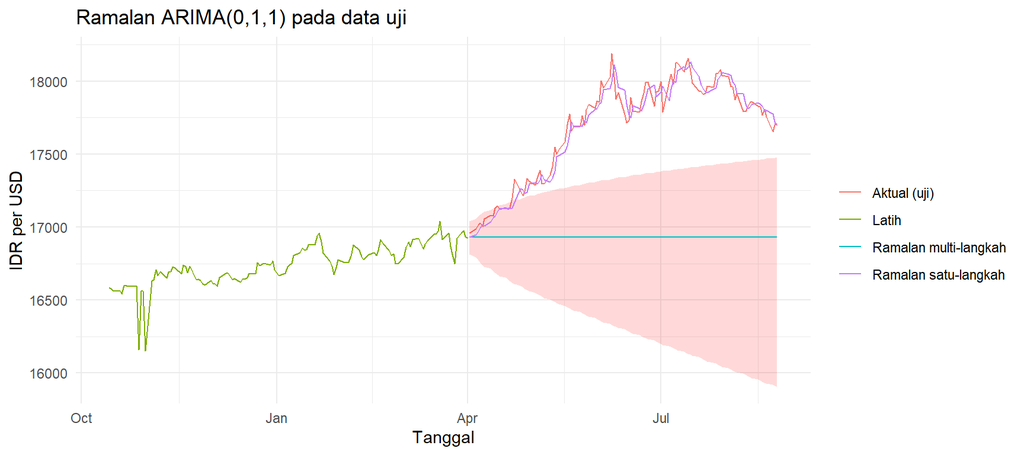

```r
h  <- length(test)
fc <- forecast(model, h = h, level = 95)

f_mean <- ibc_tr(as.numeric(fc$mean))
f_low  <- ibc_tr(as.numeric(fc$lower))
f_up   <- ibc_tr(as.numeric(fc$upper))

# ramalan satu-langkah (parameter tetap dari data latih, data baru masuk bertahap)
ref    <- Arima(z_all, model = model)
os1    <- ibc_tr(as.numeric(fitted(ref)))[(k + 1):n]

ggplot() +
  geom_line(aes(tail(d_tr, 120), tail(train, 120), colour = "Latih")) +
  geom_line(aes(d_te, test,   colour = "Aktual (uji)")) +
  geom_ribbon(aes(d_te, ymin = f_low, ymax = f_up), fill = "red", alpha = 0.15) +
  geom_line(aes(d_te, f_mean, colour = "Ramalan multi-langkah")) +
  geom_line(aes(d_te, os1,    colour = "Ramalan satu-langkah")) +
  labs(title = paste("Ramalan", best, "pada data uji"), x = "Tanggal", y = "IDR per USD", colour = "") +
  theme_minimal()
```

```r
met <- function(a, f) c(MAE = mean(abs(a - f)),
                        RMSE = sqrt(mean((a - f)^2)),
                        MAPE = mean(abs((a - f) / a)) * 100)
naif <- rep(tail(train, 1), h)
round(rbind("Multi-langkah"     = met(test, f_mean),
            "Satu-langkah"      = met(test, os1),
            "Pembanding (naif)" = met(test, naif)), 3)
```

```
##                       MAE    RMSE  MAPE
## Multi-langkah     759.628 831.650 4.258
## Satu-langkah       59.108  75.937 0.333
## Pembanding (naif) 767.781 839.104 4.304
```

```r
cat("Cakupan selang 95%:", round(mean(test >= f_low & test <= f_up) * 100, 1), "%\n")
```

```
## Cakupan selang 95%: 12.5 %
```

## 7.2 Peramalan ke depan (model dilatih ulang pada seluruh data)

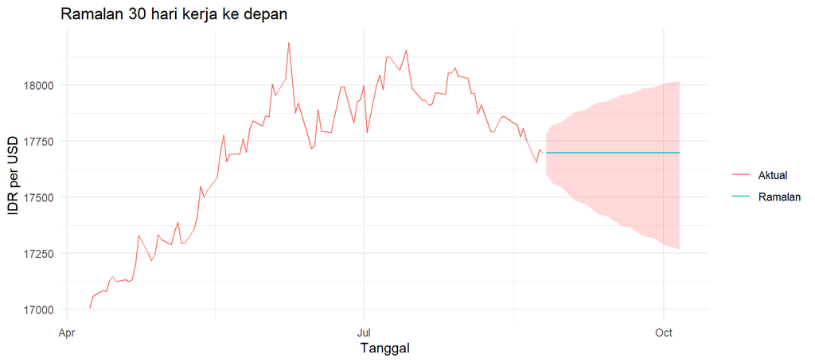

```r
H     <- 30
final <- Arima(z_all, order = as.numeric(o))
ff    <- forecast(final, h = H, level = 95)

fdate <- seq(max(d$Tanggal) + 1, by = "day", length.out = H * 2)
fdate <- fdate[!weekdays(fdate) %in% c("Saturday", "Sunday", "Sabtu", "Minggu")][1:H]

hasil <- data.frame(Tanggal = fdate,
                    Ramalan = ibc_tr(as.numeric(ff$mean)),
                    Bawah95 = ibc_tr(as.numeric(ff$lower)),
                    Atas95  = ibc_tr(as.numeric(ff$upper)))

ggplot() +
  geom_line(aes(tail(d$Tanggal, 100), tail(y, 100), colour = "Aktual")) +
  geom_ribbon(data = hasil, aes(Tanggal, ymin = Bawah95, ymax = Atas95), fill = "red", alpha = 0.15) +
  geom_line(data = hasil, aes(Tanggal, Ramalan, colour = "Ramalan")) +
  labs(title = paste("Ramalan", H, "hari kerja ke depan"), x = "Tanggal", y = "IDR per USD", colour = "") +
  theme_minimal()
```

```r
head(hasil, 10)
```

|  | Tanggal | Ramalan | Bawah95 | Atas95 |
| --- | --- | --- | --- | --- |
| 1 | 2026-08-26 | 17698.41 | 17603.32 | 17786.80 |
| 2 | 2026-08-27 | 17698.41 | 17580.19 | 17806.43 |
| 3 | 2026-08-28 | 17698.41 | 17560.44 | 17822.69 |
| 4 | 2026-08-31 | 17698.41 | 17542.81 | 17836.80 |
| 5 | 2026-09-01 | 17698.41 | 17526.68 | 17849.41 |
| 6 | 2026-09-02 | 17698.41 | 17511.67 | 17860.89 |
| 7 | 2026-09-03 | 17698.41 | 17497.54 | 17871.47 |
| 8 | 2026-09-04 | 17698.41 | 17484.14 | 17881.32 |
| 9 | 2026-09-07 | 17698.41 | 17471.33 | 17890.57 |
| 10 | 2026-09-08 | 17698.41 | 17459.02 | 17899.29 |

# 8. Kesimpulan

1. Data latih tidak stasioner dalam rataan (ADF p > 0,05) maupun ragam (selang $\lambda$ tidak memuat 1). Setelah transformasi Box-Cox dan differencing ke-1, data stasioner.
2. Model terbaik: **ARIMA(0,1,1)** (semua parameter signifikan dan AIC terkecil = -3060.4).
3. Sisaan tidak berautokorelasi dan bernilai tengah nol, tetapi tidak normal dan ada heteroskedastisitas.
4. Pengujian *overfitting* tidak memberi model yang lebih baik.
5. Hasil peramalan dan evaluasinya disajikan pada bagian 7.